# Assignment 6

Keli Niu

2024-10-28

# 1. The Gaussian distribution

## 1 (Q1)

```r
library(tidyverse)

X_samples<-seq(-4,6,length.out=100)
X_samples
```

```
##   [1] -4.00000000 -3.89898990 -3.79797980 -3.69696970 -3.59595960 -3.49494949
##   [7] -3.39393939 -3.29292929 -3.19191919 -3.09090909 -2.98989899 -2.88888889
##  [13] -2.78787879 -2.68686869 -2.58585859 -2.48484848 -2.38383838 -2.28282828
##  [19] -2.18181818 -2.08080808 -1.97979798 -1.87878788 -1.77777778 -1.67676768
##  [25] -1.57575758 -1.47474747 -1.37373737 -1.27272727 -1.17171717 -1.07070707
##  [31] -0.96969697 -0.86868687 -0.76767677 -0.66666667 -0.56565657 -0.46464646
##  [37] -0.36363636 -0.26262626 -0.16161616 -0.06060606  0.04040404  0.14141414
##  [43]  0.24242424  0.34343434  0.44444444  0.54545455  0.64646465  0.74747475
##  [49]  0.84848485  0.94949495  1.05050505  1.15151515  1.25252525  1.35353535
##  [55]  1.45454545  1.55555556  1.65656566  1.75757576  1.85858586  1.95959596
##  [61]  2.06060606  2.16161616  2.26262626  2.36363636  2.46464646  2.56565657
##  [67]  2.66666667  2.76767677  2.86868687  2.96969697  3.07070707  3.17171717
##  [73]  3.27272727  3.37373737  3.47474747  3.57575758  3.67676768  3.77777778
##  [79]  3.87878788  3.97979798  4.08080808  4.18181818  4.28282828  4.38383838
##  [85]  4.48484848  4.58585859  4.68686869  4.78787879  4.88888889  4.98989899
##  [91]  5.09090909  5.19191919  5.29292929  5.39393939  5.49494949  5.59595960
##  [97]  5.69696970  5.79797980  5.89898990  6.00000000
```

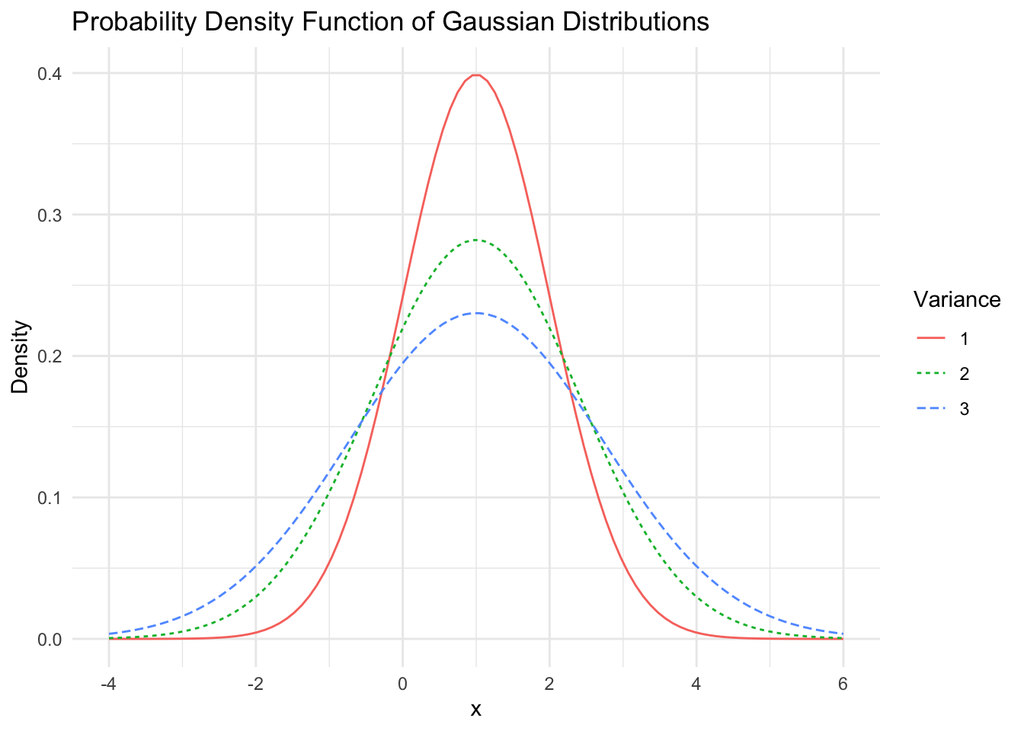

```r
density1<-dnorm(X_samples, mean=1,sd=1)
density2<-dnorm(X_samples, mean=1,sd=sqrt(2))
density3<-dnorm(X_samples, mean=1,sd=sqrt(3))

df<-data.frame(x=X_samples, density1= density1, density2 = density2, density3 = density3)

df_long <- df %>%
  pivot_longer(cols = starts_with("density"), names_to = "Variance", values_to = "Density")%>%
    mutate(Variance = case_when(Variance == "density1" ~ "1",Variance == "density2" ~ "2",Variance == "density3" ~ "3"))


ggplot(df_long, aes(x = x, y = Density, color = Variance,linetype=Variance)) +
  geom_line() +
  theme_minimal() +
  labs(title = "Probability Density Function of Gaussian Distributions",
       x = "x",
       y = "Density")
```

## 1 (Q2)

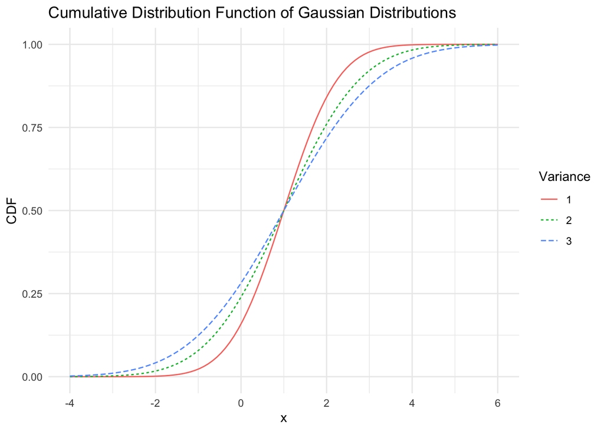

```r
x_values<-X_samples

cdf1 <- pnorm(x_values, mean = 1, sd = 1)
cdf2 <- pnorm(x_values, mean = 1, sd = sqrt(2))
cdf3 <- pnorm(x_values, mean = 1, sd = sqrt(3))


df_cdf <- data.frame(
  x = x_values,
  cdf1 = cdf1,
  cdf2 = cdf2,
  cdf3 = cdf3
)


df_cdf_long <- df_cdf %>% pivot_longer(cols = starts_with("cdf"), names_to = "Variance", values_to = "CDF")%>%
    mutate(Variance = case_when(Variance == "cdf1" ~ "1",Variance == "cdf2" ~ "2",Variance == "cdf3" ~ "3"))

ggplot(df_cdf_long, aes(x = x, y = CDF, color = Variance,linetype=Variance)) +
  geom_line() +
  theme_minimal() +
  labs(title = "Cumulative Distribution Function of Gaussian Distributions",
       x = "x",
       y = "CDF")
```

## 1 (Q3)

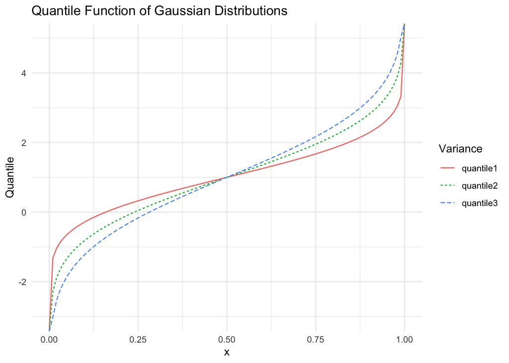

```r
xQ_values<-seq(0,1,length.out=100)

quantile1 <- qnorm(xQ_values, mean = 1, sd = 1)
quantile2 <- qnorm(xQ_values, mean = 1, sd = sqrt(2))
quantile3 <- qnorm(xQ_values, mean = 1, sd = sqrt(3))


df_quantile <- data.frame(
  x = xQ_values,
  quantile1 = quantile1,
  quantile2 = quantile2,
  quantile3 = quantile3
)


df_quantile_long <- df_quantile %>% pivot_longer(cols = starts_with("quantile"), names_to = "Variance", values_to = "Quantile")

ggplot(df_quantile_long, aes(x = x, y = Quantile, color = Variance,linetype=Variance)) +
  geom_line() +
  theme_minimal() +
  labs(title = "Quantile Function of Gaussian Distributions",
       x = "x",
       y = "Quantile")
```

#### The quantile function is the inverse of the cumulative distribution function, mapping a probability to the corresponding value of a random variable.

## 1 (Q4)

```r
set.seed(0)
n<-100

standardGaussianSample<- rnorm(n, mean = 0, sd = 1)

standardGaussianSample
```

```
##   [1]  1.262954285 -0.326233361  1.329799263  1.272429321  0.414641434
##   [6] -1.539950042 -0.928567035 -0.294720447 -0.005767173  2.404653389
##  [11]  0.763593461 -0.799009249 -1.147657009 -0.289461574 -0.299215118
##  [16] -0.411510833  0.252223448 -0.891921127  0.435683299 -1.237538422
##  [21] -0.224267885  0.377395646  0.133336361  0.804189510 -0.057106774
##  [26]  0.503607972  1.085769362 -0.690953840 -1.284599354  0.046726172
##  [31] -0.235706556 -0.542888255 -0.433310317 -0.649471647  0.726750747
##  [36]  1.151911754  0.992160365 -0.429513109  1.238304101 -0.279346282
##  [41]  1.757903090  0.560746091 -0.452783973 -0.832043296 -1.166570547
##  [46] -1.065590580 -1.563782051  1.156536997  0.832047129 -0.227328691
##  [51]  0.266137362 -0.376702719  2.441364629 -0.795339117 -0.054877474
##  [56]  0.250141323  0.618243294 -0.172623503 -2.223900274 -1.263614385
##  [61]  0.358728896 -0.011045478 -0.940649163 -0.115825322 -0.814968709
##  [66]  0.242263481 -1.425098395  0.365941123  0.248412649  0.065288182
##  [71]  0.019156392  0.257338377 -0.649010078 -0.119168762  0.664135700
##  [76]  1.100969102  0.143771481 -0.117753598 -0.912068367 -1.437586241
##  [81] -0.797089525  1.254083106  0.772142186 -0.219515627 -0.424810283
##  [86] -0.418980099  0.996986861 -0.275778029  1.256018817  0.646674390
##  [91]  1.299312303 -0.873262112  0.008370960 -0.880871723  0.596259017
##  [96]  0.119717641 -0.282173877  1.455988401  0.229019591  0.996543929
```

## 1 (Q5)

```r
beta<-1
alpha<-sqrt(3)

mean1Var3GaussianSampleA <- alpha * standardGaussianSample + beta
mean1Var3GaussianSampleA
```

```
##   [1]  3.18750099  0.43494724  3.30327989  3.20391223  1.71818003 -1.66727171
##   [7] -0.60832528  0.48952921  0.99001096  5.16498184  2.32258267 -0.38392461
##  [13] -0.98780025  0.49863785  0.48174421  0.28724233  1.43686383 -0.54485271
##  [19]  1.75462561 -1.14347942  0.61155663  1.65366843  1.23094535  2.39289709
##  [25]  0.90108817  1.87227460  2.88060770 -0.19676716 -1.22499135  1.08093210
##  [31]  0.59174427  0.05968996  0.24948451 -0.12491789  2.25876922  2.99516968
##  [37]  2.71847216  0.25606147  3.14480562  0.51615805  4.04477747  1.97124072
##  [43]  0.21575515 -0.44114126 -1.02055946 -0.84565703 -1.70854996  3.00318084
##  [49]  2.44114790  0.60625516  1.46096343  0.34753175  5.22856758 -0.37756776
##  [55]  0.90494943  1.43325748  2.07082880  0.70100732 -2.85190827 -1.18864432
##  [61]  1.62133667  0.98086867 -0.62925214  0.79938466 -0.41156721  1.41961266
##  [67] -1.46834283  1.63382862  1.43026333  1.11308245  1.03317984  1.44572314
##  [73] -0.12411843  0.79359365  2.15031678  2.90693442  1.24901951  0.79604479
##  [79] -0.57974875 -1.48997241 -0.38059956  3.17213566  2.33738950  0.61978778
##  [85]  0.26420701  0.27430518  2.72683190  0.52233844  3.17548841  2.12007290
##  [91]  3.25047492 -0.51253435  1.01449893 -0.52571458  2.03275091  1.20735704
##  [97]  0.51126051  3.52184589  1.39667357  2.72606472
```

## 1 (Q6)

```r
set.seed(0)
n <- 100
mean1Var3GaussianSampleB <- rnorm(n, mean = 1, sd = sqrt(3))


mean1Var3GaussianSampleB
```

```
##   [1]  3.18750099  0.43494724  3.30327989  3.20391223  1.71818003 -1.66727171
##   [7] -0.60832528  0.48952921  0.99001096  5.16498184  2.32258267 -0.38392461
##  [13] -0.98780025  0.49863785  0.48174421  0.28724233  1.43686383 -0.54485271
##  [19]  1.75462561 -1.14347942  0.61155663  1.65366843  1.23094535  2.39289709
##  [25]  0.90108817  1.87227460  2.88060770 -0.19676716 -1.22499135  1.08093210
##  [31]  0.59174427  0.05968996  0.24948451 -0.12491789  2.25876922  2.99516968
##  [37]  2.71847216  0.25606147  3.14480562  0.51615805  4.04477747  1.97124072
##  [43]  0.21575515 -0.44114126 -1.02055946 -0.84565703 -1.70854996  3.00318084
##  [49]  2.44114790  0.60625516  1.46096343  0.34753175  5.22856758 -0.37756776
##  [55]  0.90494943  1.43325748  2.07082880  0.70100732 -2.85190827 -1.18864432
##  [61]  1.62133667  0.98086867 -0.62925214  0.79938466 -0.41156721  1.41961266
##  [67] -1.46834283  1.63382862  1.43026333  1.11308245  1.03317984  1.44572314
##  [73] -0.12411843  0.79359365  2.15031678  2.90693442  1.24901951  0.79604479
##  [79] -0.57974875 -1.48997241 -0.38059956  3.17213566  2.33738950  0.61978778
##  [85]  0.26420701  0.27430518  2.72683190  0.52233844  3.17548841  2.12007290
##  [91]  3.25047492 -0.51253435  1.01449893 -0.52571458  2.03275091  1.20735704
##  [97]  0.51126051  3.52184589  1.39667357  2.72606472
```

```r
are_same <- identical(mean1Var3GaussianSampleA, mean1Var3GaussianSampleB)
print(are_same)
```

```
## [1] TRUE
```

## 1 (Q7)

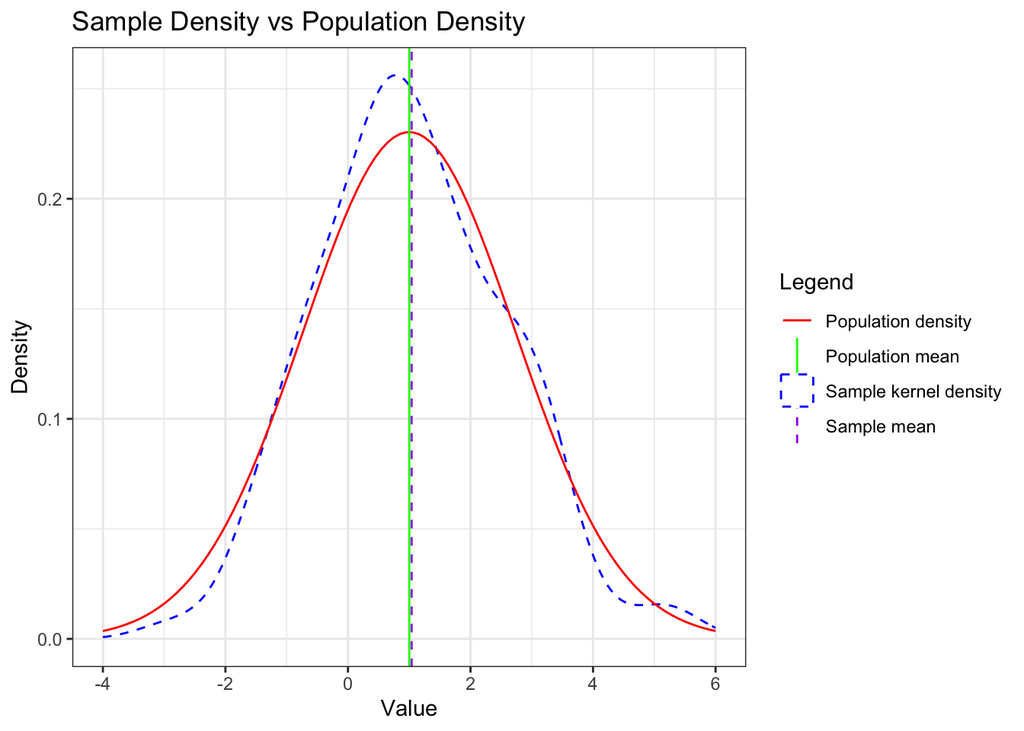

```r
x_values <- seq(-4, 6, length.out = 100)


y_values <- dnorm(x_values, mean = 1, sd = sqrt(3))


population_density_df <- data.frame(x = x_values, y = y_values)


ggplot() +
  geom_density(aes(x = mean1Var3GaussianSampleA, color = "Sample kernel density", linetype = "Sample kernel density")) +


  geom_line(data = population_density_df, aes(x = x, y = y, color = "Population density", linetype = "Population density")) +

  geom_vline(aes(xintercept = mean(mean1Var3GaussianSampleA), color = "Sample mean", linetype = "Sample mean")) +

  geom_vline(aes(xintercept = 1, color = "Population mean", linetype = "Population mean")) +

  theme_bw() +
  labs(title = "Sample Density vs Population Density",
       x = "Value",
       y = "Density") +


  scale_color_manual(name = "Legend",
                     values = c("Population density" = "red",
                                "Population mean" = "green",
                                "Sample kernel density" = "blue",
                                "Sample mean" = "purple")) +
  scale_linetype_manual(name = "Legend",
                        values = c("Population density" = "solid",
                                   "Population mean" = "solid",
                                   "Sample kernel density" = "dashed",
                                   "Sample mean" = "dashed"))
```

## 1 (Q8)

# 2. Location estimators with Gaussian data

## 2 (Q1)

## 2 (Q2)

```r
set.seed(0)

num_trials_per_sample_size <- 1000
min_sample_size <- 30
max_sample_size <- 500
sample_size_inc <- 5
mu_0 <- 1
sigma_0 <- 3

simulation_df <- crossing(trial = seq(num_trials_per_sample_size),
                          sample_size = seq(min_sample_size, max_sample_size, sample_size_inc)) %>%
  mutate(simulation = pmap(.l = list(trial, sample_size),
                           .f = ~rnorm(.y, mean = mu_0, sd = sigma_0))) %>%
  mutate(sample_md = map_dbl(.x = simulation, .f = median)) %>%
  mutate(sample_mn = map_dbl(.x = simulation, .f = mean)) %>%
  group_by(sample_size) %>%
  summarise(msq_error_md = mean((sample_md - mu_0)^2),
            msq_error_mn = mean((sample_mn - mu_0)^2))

print(simulation_df)
```

```
## # A tibble: 95 × 3
##    sample_size msq_error_md msq_error_mn
##          <dbl>        <dbl>        <dbl>
##  1          30        0.426        0.280
##  2          35        0.370        0.227
##  3          40        0.341        0.217
##  4          45        0.288        0.191
##  5          50        0.276        0.181
##  6          55        0.268        0.169
##  7          60        0.227        0.152
##  8          65        0.230        0.140
##  9          70        0.199        0.130
## 10          75        0.209        0.130
## # ℹ 85 more rows
```

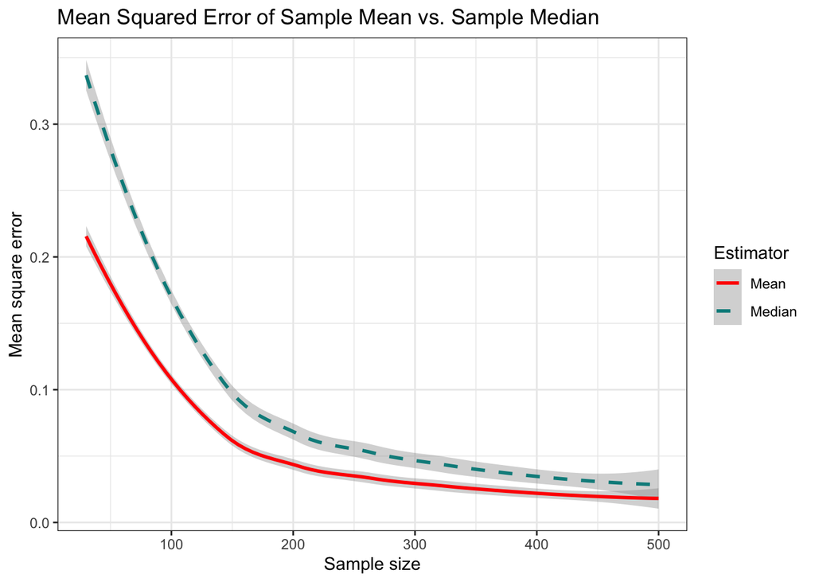

```r
ggplot(simulation_df, aes(x = sample_size)) +

  geom_smooth(aes(y = msq_error_md,color = "Median", linetype = "Median"), se=TRUE) +
  geom_smooth(aes(y = msq_error_mn, color = "Mean", linetype = "Mean"),se=TRUE) +
  theme_bw() +
  labs(title = "Mean Squared Error of Sample Mean vs. Sample Median",
       x = "Sample size",
       y = "Mean square error") +
  scale_color_manual(name = "Estimator",
                     values = c("Mean" = "red", "Median" = "cyan4")) +
  scale_linetype_manual(name = "Estimator",
                        values = c("Mean" = "solid", "Median" = "dashed")) +
  theme(legend.position = "right")
```

# 3. (**) The law of large numbers and Hoeffding’s inequality

## 3 (Q1)

# 4. Maximum likelihood estimates

## 4.1 Maximum likelihood estimates for Red tailed hawks

## 4.1 (Q1)

```r
library(tidyverse)
library(Stat2Data)
data("Hawks")


RedTailedDf <- Hawks %>%
  filter(Species == "RT") %>%
  select(Weight, Tail, Wing)


print(nrow(RedTailedDf))
```

```
## [1] 577
```

```r
print(head(RedTailedDf, 5))
```

```
##   Weight Tail Wing
## 1    920  219  385
## 2    930  221  376
## 3    990  235  381
## 4   1090  230  412
## 5    960  212  370
```

## 4.1 (Q2)

```r
n <- nrow(RedTailedDf)


mu_hat_MLE <- mean(RedTailedDf$Tail)

sigma_hat_squared_MLE <- sum((RedTailedDf$Tail - mu_hat_MLE)^2) / n

print(paste("Maximum Likelihood Estimate for Mean (μ̂ MLE):", mu_hat_MLE))
```

```
## [1] "Maximum Likelihood Estimate for Mean (μ̂ MLE): 222.149046793761"
```

```r
print(paste("Maximum Likelihood Estimate for Variance (σ̂² MLE):", sigma_hat_squared_MLE))
```

```
## [1] "Maximum Likelihood Estimate for Variance (σ̂² MLE): 210.203088346164"
```

## 4.1 (Q3)

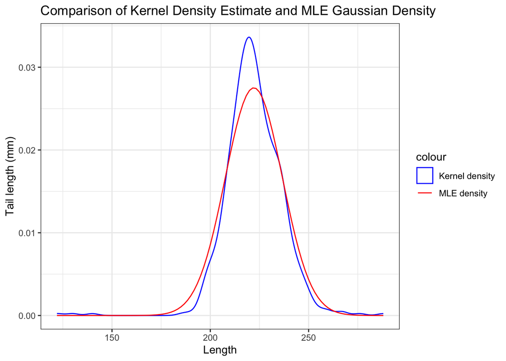

```r
sigma_hat_MLE <- sqrt(sigma_hat_squared_MLE)

ggplot() +
  geom_density(data = RedTailedDf, aes(x = Tail, color = "Kernel density")) +

  stat_function(fun = dnorm, args = list(mean = mu_hat_MLE, sd = sigma_hat_MLE),
                aes(color = "MLE density")) +


  theme_bw() +
  labs(title = "Comparison of Kernel Density Estimate and MLE Gaussian Density",
       x = "Length",
       y = "Tail length (mm)") +

  scale_color_manual(values = c("Kernel density" = "blue", "MLE density" = "red"))
```

## 4.2 Unbiased estimation of the population variance

## 4.2 (Q1)

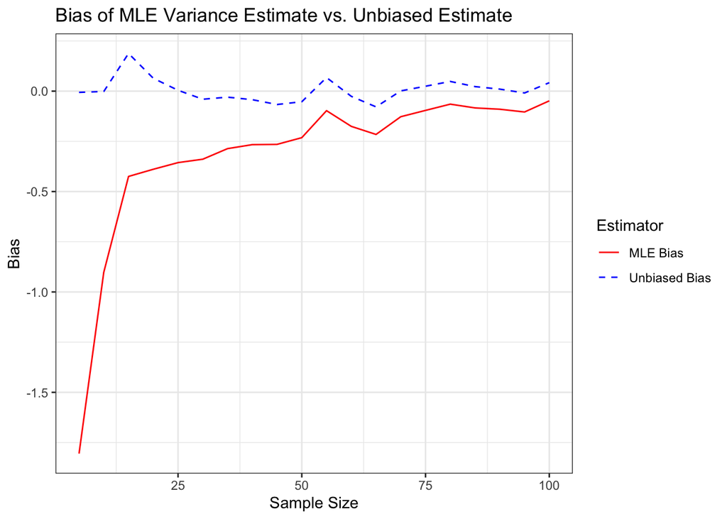

```r
set.seed(0)
mu_0 <- 1
sigma_0 <- 3
num_trials <- 1000
sample_sizes <- seq(5, 100, by = 5)

bias_results <- data.frame(sample_size = integer(),
                           bias_mle = numeric(),
                           bias_unbiased = numeric())

for (n in sample_sizes) {
  V_mle_list <- numeric(num_trials)
  V_unbiased_list <- numeric(num_trials)

  for (i in 1:num_trials) {
    sample_data <- rnorm(n, mean = mu_0, sd = sigma_0)

    sample_mean <- mean(sample_data)

    V_mle <- sum((sample_data - sample_mean)^2) / n
    V_mle_list[i] <- V_mle

    V_unbiased <- sum((sample_data - sample_mean)^2) / (n - 1)
    V_unbiased_list[i] <- V_unbiased
  }

  bias_mle <- mean(V_mle_list) - sigma_0^2
  bias_unbiased <- mean(V_unbiased_list) - sigma_0^2

  bias_results <- rbind(bias_results, data.frame(sample_size = n,
                                                 bias_mle = bias_mle,
                                                 bias_unbiased = bias_unbiased))
}

ggplot(bias_results, aes(x = sample_size)) +
  geom_line(aes(y = bias_mle, color = "MLE Bias"), linetype = "solid") +
  geom_line(aes(y = bias_unbiased, color = "Unbiased Bias"), linetype = "dashed") +
  theme_bw() +
  labs(title = "Bias of MLE Variance Estimate vs. Unbiased Estimate",
       x = "Sample Size",
       y = "Bias") +
  scale_color_manual(name = "Estimator",
                     values = c("MLE Bias" = "red", "Unbiased Bias" = "blue"))
```

## 4.2 (Q2)

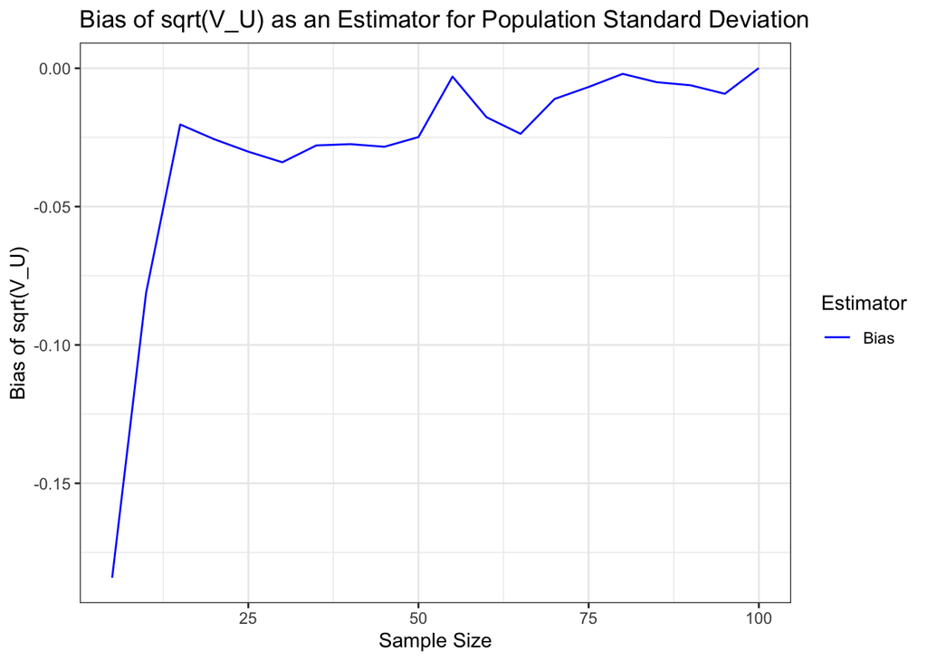

```r
set.seed(0)
mu_0 <- 1
sigma_0 <- 3
num_trials <- 1000
sample_sizes <- seq(5, 100, by = 5)


sqrt_bias_results <- data.frame(sample_size = integer(),
                                bias_sqrt_unbiased = numeric())


for (n in sample_sizes) {

  sqrt_V_unbiased_list <- numeric(num_trials)

  for (i in 1:num_trials) {

    sample_data <- rnorm(n, mean = mu_0, sd = sigma_0)


    sample_mean <- mean(sample_data)


    V_unbiased <- sum((sample_data - sample_mean)^2) / (n - 1)


    sqrt_V_unbiased <- sqrt(V_unbiased)
    sqrt_V_unbiased_list[i] <- sqrt_V_unbiased
  }

  bias_sqrt_unbiased <- mean(sqrt_V_unbiased_list) - sigma_0

  sqrt_bias_results <- rbind(sqrt_bias_results, data.frame(sample_size = n,
                                                           bias_sqrt_unbiased = bias_sqrt_unbiased))
}

ggplot(sqrt_bias_results, aes(x = sample_size, y = bias_sqrt_unbiased)) +
  geom_line(aes(color="Bias")) +
  theme_bw() +
  labs(title = "Bias of sqrt(V_U) as an Estimator for Population Standard Deviation",
       x = "Sample Size",
       y = "Bias of sqrt(V_U)")+
  scale_color_manual(name = "Estimator",
                     values = c("Bias" = "blue"))
```

```r
# 虽然VU对整体方差sigma方是无偏的，但其平方根是非线性的，根据詹森不等式得到其在较低样本时会低于整体标准差
```

## 4.2 (Q3)

## 4.3 Maximum likelihood estimation with the Poisson distribution

## 4.3 (Q1)

The likelihood function can be written as:

$$l(\lambda) = e^{-n\lambda} \cdot \lambda^{n\bar{X}} \cdot \prod_{i=1}^n
\frac{1}{X_i!}$$

Taking the natural logarithm of the likelihood function, we obtain the log-likelihood function:

$$\log l(\lambda) = \log \left( e^{-n\lambda} \cdot \lambda^{n\bar{X}}
\cdot \prod_{i=1}^n \frac{1}{X_i!} \right)$$

Using the properties of logarithms (turning multiplication into addition), we can write:

$$\log l(\lambda) = -n\lambda + {n\bar{X}} \log \lambda + \sum_{i=1}^n
\log \left( \frac{1}{X_i!} \right)$$

Since the last term is a constant with respect to $\lambda$, it can be ignored when differentiating:

$$\log l(\lambda) = -n\lambda + {n\bar{X}} \log \lambda + \text{constant}$$

Now, to find the maximum likelihood estimate, we take the derivative of the log-likelihood function with respect to $\lambda$:

$$\frac{\partial}{\partial \lambda} \log l(\lambda) = -n +
\frac{n\bar{X}}{\lambda}$$

To find the maximum likelihood estimate $\hat{\lambda}$, we set the derivative equal to zero:

$$-n + \frac{n\bar{X}}{\lambda} = 0$$

Solving this equation gives:

$$\hat{\lambda} = {\bar{X}}$$

## 4.3 (Q2)

To verify whether $\lambda = \bar{X}$ is a maximum of the log-likelihood function, we can take the second derivative of the log-likelihood function and check its sign.

Taking the derivative of the log-likelihood function $\log l(\lambda)$ again with respect to $\lambda$, we obtain the second derivative:

$$\frac{\partial^2}{\partial \lambda^2} \log l(\lambda) =
-\frac{n\bar{X}}{\lambda^2}$$

Since $\lambda > 0$ and $n > 0$, it can be seen that:

$$\frac{\partial^2}{\partial \lambda^2} \log l(\lambda) < 0$$

This indicates that the log-likelihood function is concave down at $\lambda = \bar{X}$, meaning that it reaches a maximum at this point.

## 4.3 (Q3)

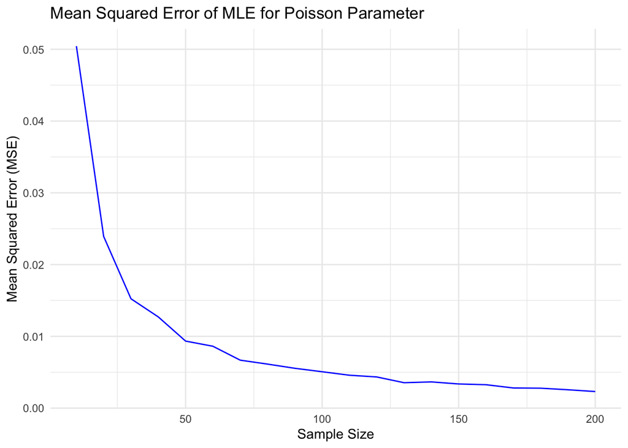

```r
set.seed(0)
lambda_0 <- 0.5
sample_sizes <- seq(10, 200, by = 10)
num_trials <- 1000


mse_results <- data.frame(sample_size = integer(),
                          mse = numeric())


for (n in sample_sizes) {
  lambda_mle_list <- numeric(num_trials)

  for (i in 1:num_trials) {

    sample_data <- rpois(n, lambda = lambda_0)

    # 计算最大似然估计 (MLE) = 样本均值
    lambda_mle <- mean(sample_data)
    lambda_mle_list[i] <- lambda_mle
  }

  # 计算均方误差 (MSE)
  mse <- mean((lambda_mle_list - lambda_0)^2)

  mse_results <- rbind(mse_results, data.frame(sample_size = n, mse = mse))
}

ggplot(mse_results, aes(x = sample_size, y = mse)) +
  geom_line(color = "blue") +
  theme_minimal() +
  labs(title = "Mean Squared Error of MLE for Poisson Parameter",
       x = "Sample Size",
       y = "Mean Squared Error (MSE)") +
  theme(legend.position = "none")
```

## 4.3 (Q4)

```r
data_file <- "VonBortkiewicz.csv"
horse_data <- read.csv(data_file)

lambda_mle <- mean(horse_data$fatalities)

print(paste("The maximum likelihood estimate for lambda (MLE) is:", lambda_mle))
```

```
## [1] "The maximum likelihood estimate for lambda (MLE) is: 0.7"
```

```r
prob_no_fatalities <- dpois(0, lambda = lambda_mle)

print(paste("The estimated probability that a cavalry corps has no fatalities in a single year is:", prob_no_fatalities))
```

```
## [1] "The estimated probability that a cavalry corps has no fatalities in a single year is: 0.49658530379141"
```

## 4.3 (Q5)

## 4.4 Maximum likelihood estimation for the exponential distribution

## 4.4 (Q1)

The likelihood function is the product of the probability density for all sample points:

$$l(\lambda) = \prod_{i=1}^n p_\lambda(X_i) = \prod_{i=1}^n \lambda
e^{-\lambda X_i}$$

Expanding this, we get:

$$l(\lambda) = \lambda^n e^{-\lambda \sum_{i=1}^n X_i}$$

To simplify the maximization process, we take the natural logarithm of the likelihood function to obtain the log-likelihood function:

$$\log l(\lambda) = \log(\lambda^n e^{-\lambda \sum_{i=1}^n X_i})$$

Using the properties of logarithms, this can be written as:

$$\log l(\lambda) = n \log \lambda - \lambda \sum_{i=1}^n X_i$$

To find the maximum likelihood estimate, we differentiate the log-likelihood function with respect to $\lambda$:

$$\frac{\partial}{\partial \lambda} \log l(\lambda) = \frac{n}{\lambda} -
\sum_{i=1}^n X_i$$

To find the maximum likelihood estimate $\hat{\lambda}$, we set the derivative equal to zero:

$$\frac{n}{\lambda} - \sum_{i=1}^n X_i = 0$$

Solving for $\lambda$, we get:

$$\hat{\lambda} = \frac{n}{\sum_{i=1}^n X_i}= {\frac{1}{\bar{X}}}$$

## 4.4 (Q2)

```r
data_file <- "CustomerPurchase.csv"
purchase_data <- read.csv(data_file)
head(purchase_data)
```

```
##   Time Purchase
## 1  564     3.25
## 2  571   504.85
## 3  578     7.60
## 4  600    43.45
## 5  745     9.30
## 6  806   352.80
```

```r
purchase_data <- purchase_data %>%
  mutate(time_diffs = lead(Time) - Time)

print(head(purchase_data))
```

```
##   Time Purchase time_diffs
## 1  564     3.25          7
## 2  571   504.85          7
## 3  578     7.60         22
## 4  600    43.45        145
## 5  745     9.30         61
## 6  806   352.80         27
```

## 4.4 (Q3)

```r
time_diffs <- na.omit(purchase_data$time_diffs)
lambda_mle <- 1 / mean(time_diffs)
print(paste("The maximum likelihood estimate for lambda (MLE) is:", lambda_mle))
```

```
## [1] "The maximum likelihood estimate for lambda (MLE) is: 0.0200779237101741"
```

## 4.4 (Q4)

```r
prob_exceed_60 <- 1 - pexp(60, rate = lambda_mle)


print(paste("The estimated probability that the arrival time exceeds one minute is:", prob_exceed_60))
```

```
## [1] "The estimated probability that the arrival time exceeds one minute is: 0.299789288548175"
```

# 5. Confidence intervals

## 5.1 Student’s t-confidence intervals

## 5.1 (Q1)

The formula for calculating the confidence interval using Student’s t-distribution is as follows:

$$\text{Confidence Interval} = \left( \bar{X} - t \cdot
\frac{s}{\sqrt{n}}, \; \bar{X} + t \cdot \frac{s}{\sqrt{n}} \right)$$

The width of the confidence interval can be expressed as:

$$\text{Width} = 2 \cdot t \cdot \frac{s}{\sqrt{n}}$$

### Analysis of Influencing Factors

1. **Increase in Sample Mean**
   - **Effect**: If the sample mean increases, the center of the confidence interval will shift, but the width of the interval will not be affected.
   - **Reason**: The width of the confidence interval is related to the standard deviation, sample size, and the t-value, but it is independent of the sample mean.
2. **Increase in Sample Standard Deviation**
   - **Effect**: If the sample standard deviation $s$ increases, the width of the confidence interval will **increase**.
   - **Reason**: A larger standard deviation means the data is more dispersed, which implies greater uncertainty about the population mean. Therefore, the confidence interval becomes wider.
3. **Increase in Sample Size**
   - **Effect**: If the sample size $n$ increases (keeping the standard deviation constant), the width of the confidence interval will **decrease**.
   - **Reason**: Increasing the sample size decreases the standard error of the mean $\frac{s}{\sqrt{n}}$. With a larger sample size, the estimate of the population mean becomes more precise, leading to a narrower confidence interval.

## 5.1 (Q2)

```r
red_tailed_weights <- Hawks %>%
  filter(Species == "RT") %>%
  select(Weight) %>%
  drop_na() %>%
  pull(Weight)


alpha <- 0.01
sample_size <- length(red_tailed_weights)
sample_mean <- mean(red_tailed_weights)
sample_sd <- sd(red_tailed_weights)

t_value <- qt(1 - alpha / 2, df = sample_size - 1)

confidence_interval_l <- sample_mean - t_value * sample_sd / sqrt(sample_size)
confidence_interval_u <- sample_mean + t_value * sample_sd / sqrt(sample_size)
confidence_interval <- c(confidence_interval_l, confidence_interval_u)


print(confidence_interval)
```

```
## [1] 1073.984 1114.877
```

## 5.1 (Q3)

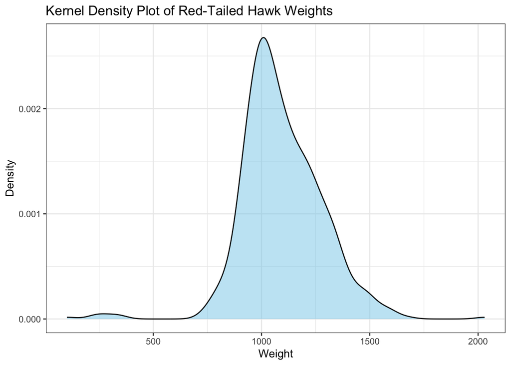

```r
ggplot(data.frame(Weight = red_tailed_weights), aes(x = Weight)) +
  geom_density(fill = "skyblue", alpha = 0.5) +
  theme_bw() +
  labs(title = "Kernel Density Plot of Red-Tailed Hawk Weights",
       x = "Weight",
       y = "Density")
```

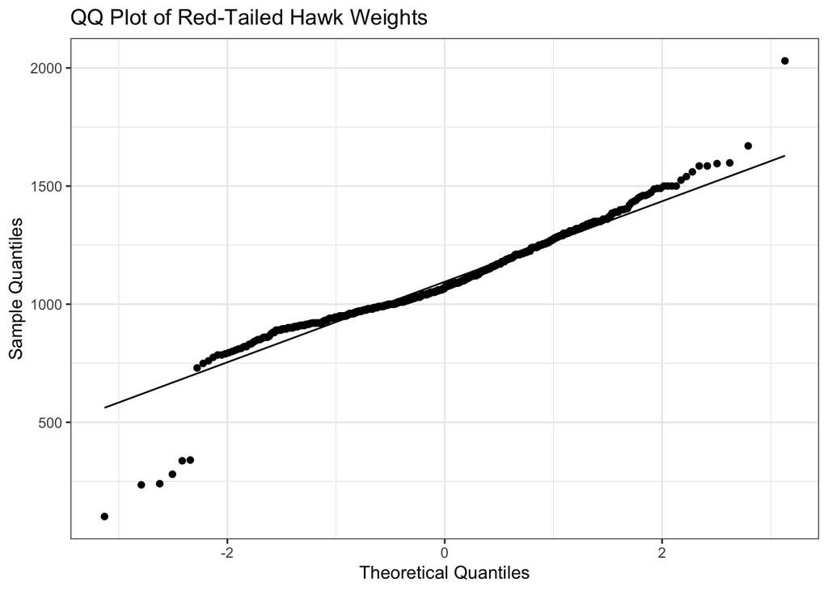

```r
ggplot(data.frame(Weight = red_tailed_weights), aes(sample = Weight)) +
  stat_qq() +
  stat_qq_line() +
  theme_bw() +
  labs(title = "QQ Plot of Red-Tailed Hawk Weights",
       x = "Theoretical Quantiles",
       y = "Sample Quantiles")
```

## 5.2 Investigating coverage for Student’s t intervals

## 5.2 (Q1)

```r
library(dplyr)
library(purrr)
library(ggplot2)

# 置信水平列表
confidence_levels <- c(0.90, 0.95, 0.99)
num_trials <- 100000
sample_size <- 30
mu_0 <- 1
sigma_0 <- 3

set.seed(0)

student_t_confidence_interval <- function(sample, confidence_level) {
  sample <- sample[!is.na(sample)]
  n <- length(sample)
  mu_est <- mean(sample)
  sig_est <- sd(sample)
  alpha <- 1 - confidence_level
  t <- qt(1 - alpha / 2, df = n - 1)
  l <- mu_est - (t / sqrt(n)) * sig_est
  u <- mu_est + (t / sqrt(n)) * sig_est
  return(c(l, u))
}

results <- list()

for (confidence_level in confidence_levels) {
  alpha <- 1 - confidence_level

  single_coverage_simulation_df <- data.frame(trial = seq(num_trials)) %>%
    mutate(sample = map(.x = trial, .f = ~rnorm(n = sample_size, mean = mu_0, sd = sigma_0))) %>%
    mutate(ci_interval = map(.x = sample, .f = ~student_t_confidence_interval(.x, confidence_level))) %>%
    mutate(cover = map_lgl(.x = ci_interval, .f = ~((min(.x) <= mu_0) & (max(.x) >= mu_0)))) %>%
    mutate(ci_length = map_dbl(.x = ci_interval, .f = ~ (max(.x) - min(.x))))

  coverage_probability <- mean(single_coverage_simulation_df$cover)

  results[[as.character(confidence_level)]] <- coverage_probability
}

coverage_results_df <- data.frame(
  Confidence_Level = confidence_levels,
  Coverage_Probability = unlist(results)
)

print(coverage_results_df)
```

```
##      Confidence_Level Coverage_Probability
## 0.9              0.90              0.89953
## 0.95             0.95              0.95011
## 0.99             0.99              0.98970
```

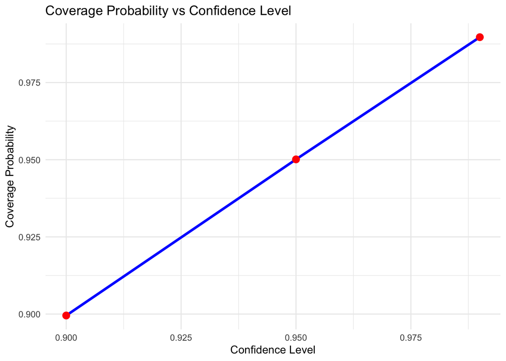

```r
ggplot(coverage_results_df, aes(x = Confidence_Level, y = Coverage_Probability)) +
  geom_line(color = "blue", size = 1.2) +
  geom_point(color = "red", size = 3) +
  theme_minimal() +
  labs(title = "Coverage Probability vs Confidence Level",
       x = "Confidence Level",
       y = "Coverage Probability")
```

## 5.2 (Q2)

```r
results2 <- list()

for (confidence_level in confidence_levels) {
  alpha <- 1 - confidence_level

  single_coverage_simulation_df <- data.frame(trial = seq(num_trials)) %>%

    mutate(sample = map(.x = trial, .f = ~rnorm(n = sample_size, mean = mu_0, sd = sigma_0))) %>%
    mutate(ci_interval = map(.x = sample, .f = ~student_t_confidence_interval(.x, confidence_level))) %>%
    mutate(ci_length = map_dbl(.x = ci_interval, .f = ~ (max(.x) - min(.x))))

  avg_ci_length <- mean(single_coverage_simulation_df$ci_length)

  results2[[as.character(confidence_level)]] <- avg_ci_length
}

ci_length_results_df <- data.frame(
  Confidence_Level = confidence_levels,
  Average_CI_Length = unlist(results2)
)

print(ci_length_results_df)
```

```
##      Confidence_Level Average_CI_Length
## 0.9              0.90          1.845538
## 0.95             0.95          2.221197
## 0.99             0.99          2.991790
```

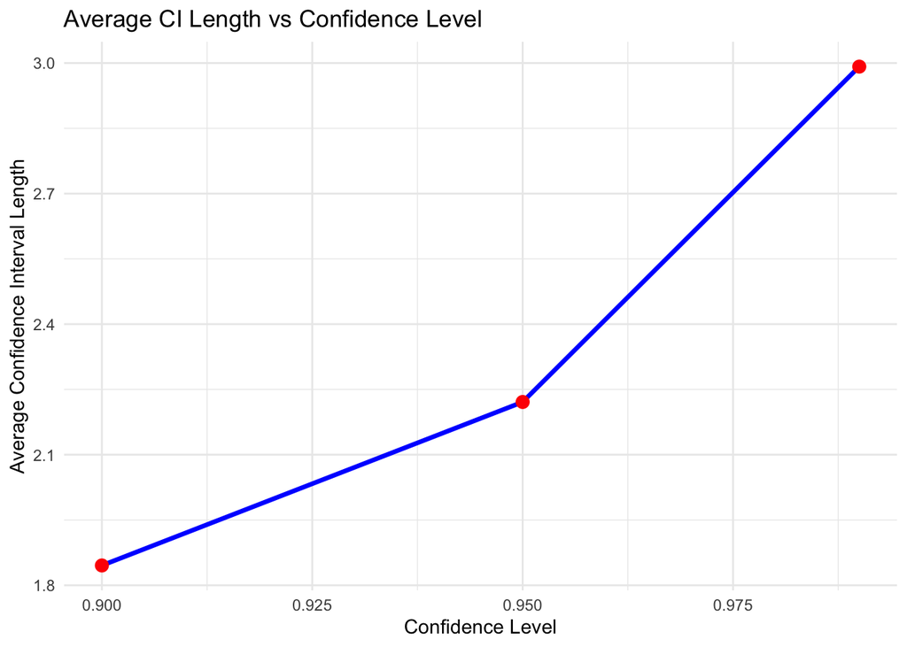

```r
ggplot(ci_length_results_df, aes(x = Confidence_Level, y = Average_CI_Length)) +
  geom_line(color = "blue", size = 1.2) +
  geom_point(color = "red", size = 3) +
  theme_minimal() +
  labs(title = "Average CI Length vs Confidence Level",
       x = "Confidence Level",
       y = "Average Confidence Interval Length")
```